# Group by & Summarize

## 9 Including missing combinations in summaries

- When you use `group_by()` and `summarize()` on multiple variables,
- You obtain a **summary statistic for every unique combination** of the grouped variables **present in the data.**
- Some combinations **are not present in the data**
- Let’s create an **artificial** example to observe this.
- We artificially drop all male children from the `yao` data frame.

```r
yao_no_male_children <-
  yao %>%
  # we leave out all male children
  filter(!(age_category_3=="Child" & sex == "Male"))
```

Let’s see the missing combination:

```r
yao_no_male_children %>%
  # let's group by sex and age_category_3
  group_by(sex, age_category_3) %>%
  # let's get the number of individuals
  summarise(number_of_individuals = n())
```

```
## # A tibble: 5 × 3
## # Groups:   sex [2]
##   sex    age_category_3 number_of_individuals
##   <chr>  <chr>                          <int>
## 1 Female Adult                            368
## 2 Female Child                            155
## 3 Female Senior                            26
## 4 Male   Adult                            267
## 5 Male   Senior                            19
```

Let’s include this **missing combinations:**

```r
yao_no_male_children %>%
  # For these combinations, you must convert the variables to factors
  mutate(age_category_3 = as.factor(age_category_3),
         sex = as.factor(sex)) %>%
  # Note the the .drop = FALSE argument
  group_by(age_category_3, sex, .drop = FALSE) %>%
  summarise(count = n())
```

```
## # A tibble: 6 × 3
## # Groups:   age_category_3 [3]
##   age_category_3 sex    count
##   <fct>          <fct>  <int>
## 1 Adult          Female   368
## 2 Adult          Male     267
## 3 Child          Female   155
## 4 Child          Male       0
## 5 Senior         Female    26
## 6 Senior         Male      19
```

- Let’s see one more example
- We will calculate the **average age** **by sex and education group**.
- These combinations do not include the group “Female—Other”.

```r
yao %>%
  # let's group by WITHOUT accounting for missing combinations
  # we group by sex and highest_eduction
  group_by( sex, highest_education) %>%
  # we summarize to have the mean age
  summarise(count = mean(age, na.rm = TRUE))
```

```
## # A tibble: 13 × 3
## # Groups:   sex [2]
##    sex    highest_education     count
##    <chr>  <chr>                 <dbl>
##  1 Female Doctorate              28
##  2 Female No formal instruction  45.6
##  3 Female No response            35
##  4 Female Primary                26.8
##  5 Female Secondary              28.8
##  6 Female University             31.5
##  7 Male   Doctorate              42.2
##  8 Male   No formal instruction  37.9
##  9 Male   No response            22
## 10 Male   Other                   5.5
## 11 Male   Primary                22.9
## 12 Male   Secondary              29.4
## 13 Male   University             31.9
```

There are 7 rows for men but only 6 rows for women.

Let’s include this missing combination:

```r
yao %>%
  # we need to make sure the grouping variables are factors
  mutate(highest_education = as.factor(highest_education),
         sex = as.factor(sex)) %>%
  # we group by sex and highest_education
  group_by(highest_education, sex, .drop = FALSE) %>%
  # we summarize for mean age
  summarize(mean_age = mean(age))
```

```
## # A tibble: 14 × 3
## # Groups:   highest_education [7]
##    highest_education     sex    mean_age
##    <fct>                 <fct>     <dbl>
##  1 Doctorate             Female     28
##  2 Doctorate             Male       42.2
##  3 No formal instruction Female     45.6
##  4 No formal instruction Male       37.9
##  5 No response           Female     35
##  6 No response           Male       22
##  7 Other                 Female    NaN
##  8 Other                 Male        5.5
##  9 Primary               Female     26.8
## 10 Primary               Male       22.9
## 11 Secondary             Female     28.8
## 12 Secondary             Male       29.4
## 13 University            Female     31.5
## 14 University            Male       31.9
```

PRACTICE TIME !

Using the `yao` data frame, let’s calculate the median age when grouping by neighborhood, age_category, and gender

Note, we want all possible combinations of these three variables (not just those present in our data).

Pay attention to two data wrangling imperatives! - convert your grouping variables to factors beforehand using `mutate()` - calculate your statistic, the median, while removing any `NA` values.

[output not shown]

```r
Q_median_age_by_neighborhood_agecategory_sex <-
  yao %>%
  mutate(neighborhood = as.factor(neighborhood),
         age_category_3 = as.factor(age_category_3),
         sex = as.factor(sex)) %>%
  group_by(neighborhood, age_category_3, sex, .drop = FALSE )%>%
  summarise(median_age = median(age))
Q_median_age_by_neighborhood_agecategory_sex
```

[output not shown]

**Why include missing combinations?**

- Let’s see one use case: plotting with {ggplot}.
- Let’s make a **dodged bar chart**
- With the age-sex counts of `yao_no_male_children`

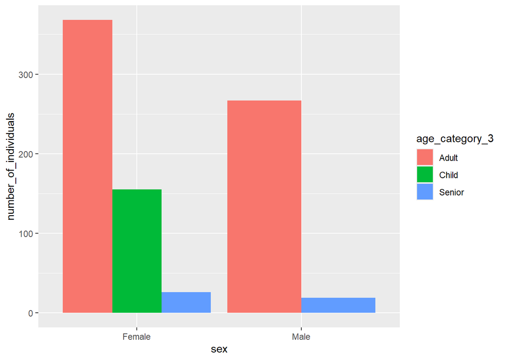

```r
yao_no_male_children %>%
  group_by(sex, age_category_3) %>%
  summarise(number_of_individuals = n()) %>%
  ungroup() %>%

  # pass the output to ggplot
  ggplot() +
  geom_col(aes(x = sex, y = number_of_individuals, fill = age_category_3),
           position = "dodge")
```

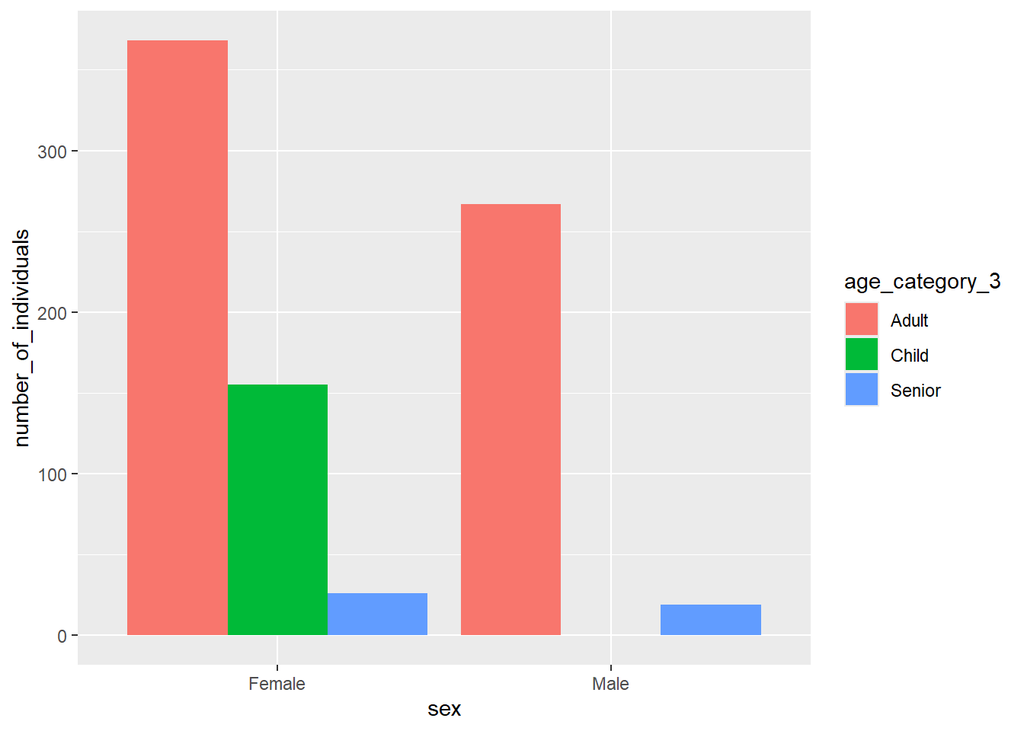

```r
yao_no_male_children %>%
  mutate(sex = as.factor(sex),
         age_category_3 = as.factor(age_category_3)) %>%
  group_by(sex, age_category_3, .drop = FALSE) %>%
  summarise(number_of_individuals = n()) %>%
  ungroup() %>%

  # pass the output to ggplot
  ggplot() +
  geom_col(aes(x = sex, y = number_of_individuals, fill = age_category_3),
           position = "dodge")
```

Much better!

By the way, this output can be improved slightly by setting the factor levels for age to their proper ascending order: first “Child”, then “Adult” then “Senior”:

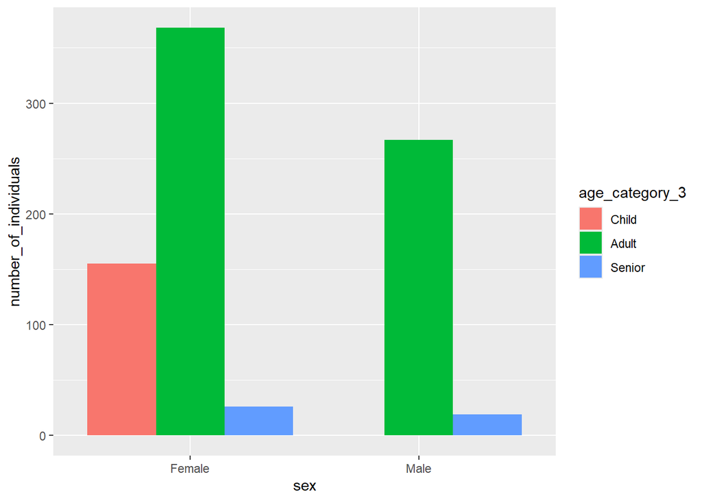

```r
yao_no_male_children %>%
  mutate(sex = as.factor(sex),
         age_category_3 = factor(age_category_3,
                                 levels = c("Child",
                                            "Adult",
                                            "Senior"))) %>%
  group_by(sex, age_category_3, .drop = FALSE) %>%
  summarise(number_of_individuals = n()) %>%
  ungroup() %>%

  # pass the output to ggplot
  ggplot() +
  geom_col(aes(x = sex, y = number_of_individuals, fill = age_category_3),
           position = "dodge")
```

## 10 Learning objectives

1. You can use `dplyr::summarize()` to extract summary statistics from datasets.
2. You can use `dplyr::group_by()` to group data by one or more variables before performing operations on them.
3. You understand why and how to **ungroup** grouped data frames.
4. You can use `dplyr::n()` together with `group_by()`-`summarize()` to count rows per group.
5. You can use `sum()` together with `group_by()`-`summarize()` to count rows that meet a condition.
6. You can use `dplyr::count()` as a handy function to count rows per group.